# 商圏内の地域メッシュデータの可視化

笹山商店街，六角橋商店街周辺の高齢者割合

[岩田真一郎](https://shinichiro-iwata.github.io/)（[神奈川大学経済学部](https://www.econ.kanagawa-u.ac.jp/)）

2024-03-05作成，2025-02-11改訂

# 1 目的

ある地点周辺の統計地図の作成，および統計量の計算を試みる．ここでは，商店街を一点で表し，その[商圏](https://ja.wikipedia.org/wiki/%E5%95%86%E5%9C%8F)を描写．

- 商圏として一次商圏（ここでは半径1.2kmの円として定義）を考え，その商圏内の高齢者割合（メッシュデータ）を可視化．[^1]
  - 一次商圏の高齢者を65歳以上人口と総人口から計算．
  - 対象地区は横浜市保土ケ谷区の[笹山商店街](https://shotengai-kanagawa.com/mall/yokohama/y-hodogaya/mall80.html)（ピンクの点を中心としたピンクの円）と神奈川区の[六角橋商店街](https://www.rokkakubashi.jp/)（緑の点を中心として緑の円）．[^2]

[interactive chart not shown]

**参考：横浜市内商店街の商圏実態**

今回は利用しないが，下記のような情報源もある．

- [商店街に関する調査](https://www.city.yokohama.lg.jp/business/kigyoshien/tokei-chosa/shogyocyosa/)
  - [平成29年度 データで見る商店街事業 商店街商圏データ](https://www.city.yokohama.lg.jp/business/kigyoshien/tokei-chosa/shogyocyosa/shogyocyosa.html)：主に町丁目単位で集計，EXELデータあり．

パッケージ：`sf`，`tidyverse`，`units`

```r
library(sf)
library(tidyverse)

#商圏半径の付与に利用
library(units)
```

# 2 行政区域と商店街ポイント

## 2.1 行政区域データダウンロード

- [国土数値情報ダウンロードサービス](https://nlftp.mlit.go.jp/ksj/) > 行政区域（ポリゴン） > 神奈川県 > 神奈川 世界測地系 2024年（令和6年） 4.33MB N03-20240101_14_GML.zip
  - ダウンロードしたZIPファイルは同じフォルダ（ディレクトリ）に納め，ZIPファイルを選択 > 右クリック > すべて展開 > 展開先の選択とファイルの選択 > 展開を実行する．展開後は最初にダウンロードしたZIPファイルを削除．
  - シェープファイルの読込（`read_sf()`）：行政区域を`Kanagawa`と名付ける．
    - `st_transform()`：地理座標系の投影変換（`JGD2011`→`WGS84`）．
    - オブジェクト`Kanagawa`から横浜市の行政区域を抜き出し（`filter()`），オブジェクト名を`Yokohama`とする．
    - 対象商店街周辺の行政区域の抜き出し（`filter()`），オブジェクト名を`periphery`とする．

```r
#神奈川県の行政区域（2024年・令和6年）
Kanagawa <-
  read_sf("N03-20240101_14_GML/N03-20240101_14.shp")

#世界測地系を指定
Kanagawa <-
  Kanagawa %>%
  st_transform("WGS84")
```

```r
#横浜市
Kanagawa %>%
  filter(N03_004=="横浜市")->
  Yokohama

#周辺区
Yokohama %>%
  filter(N03_005=="保土ケ谷区" |
           N03_005=="旭区" |
           N03_005=="神奈川区" |
           N03_005=="緑区" |
           N03_005=="港北区") ->
  periphery
```

## 2.2 商店街ポイント

- ここでは，[商店街に行こう！ in かながわ](https://shotengai-kanagawa.com/)の商店街基本情報から商店街の所在地住所を取得し，[Mapfun](https://mapfan.com/)にその住所を入力し，緯度経度を得る．

```r
#笹山商店街のポイント（世界測地系）
Sasayama_ss_sfg <-
  st_point(c(139.567458, 35.4870312))

#世界測地系を指定
Sasayama_ss_sfc <-
  st_sfc(Sasayama_ss_sfg, crs="WGS84")

#六角橋商店街のポイント（世界測地系）
Rokkakubashi_ss_sfg <-
  st_point(c(139.6260256, 35.4875658))

#世界測地系を指定
Rokkakubashi_ss_sfc <-
  st_sfc(Rokkakubashi_ss_sfg, crs="WGS84")
```

**対象商店街周辺の行政区域の可視化**

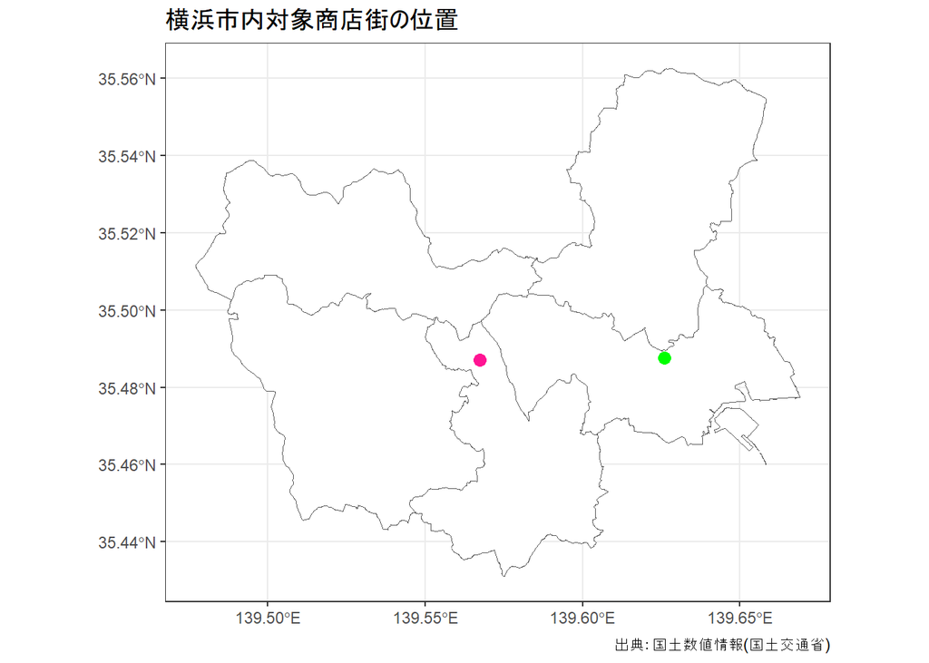

```r
#完成図
ggplot()+
  geom_sf(data=periphery, fill="white")+
  geom_sf(data=Sasayama_ss_sfc,
             color="deeppink", size=3)+
  geom_sf(data=Rokkakubashi_ss_sfc,
             color="green", size=3)+
  labs(caption="出典：国土数値情報(国土交通省)")+
  ggtitle("横浜市内対象商店街の位置")+
  theme_bw()
```

**統計データ：500mメッシュ**

[市区町村別メッシュ・コード一覧](https://www.stat.go.jp/data/mesh/m_itiran.html)（3次メッシュの情報）から保土ケ谷区や神奈川区のコードの最初の4桁が5339からはじまることがわかる．

**人口**

- [統計地理情報システム](https://www.e-stat.go.jp/gis) > 統計データダウンロード > 国勢調査 > 2020年 > 4次メッシュ（500mメッシュ） > 人口及び世帯 > 都道府県で絞込みはコチラ > 14 神奈川県 > M5339 [^3]
- `read.table()`を用いてデータを読込．`pop`と名付ける．

```r
#人口
pop <-
  read.table("tblT001101H5339/tblT001101H5339.txt",
             header=TRUE, sep=",",
             fileEncoding = "CP932")

#便宜上1行目削除（データ名が2行にわたるため）
pop %>%
  slice(-1) ->
  pop

#メッシュデータと結合するため，KEY_CODEのデータ型変換
pop %>%
  mutate(KEY_CODE=as.character(KEY_CODE)) ->
  pop
```

**境界**

メッシュデータの人口総数を地図上に可視するには，シェープファイルと結合する必要がある．そこで，境界データをダウンロードし，結合する．

```r
mesh <-
  read_sf("HDDSWH5339/MESH05339.shp")

#データ結合
mesh_pop <-
  left_join(mesh, pop, by=c("KEY_CODE"))

#人口総数，65歳以上人口総数を数値（integer：整数）に変更
mesh_pop <-
  mesh_pop %>%
  mutate(population=as.integer(T001101001),
         elderly=as.integer(T001101019),
         elderly_ratio=elderly/population*100)
```

**高齢者割合の可視化**

`mesh`の境界ボックス（Bounding box）は広範囲に及ぶ．ここでは，周辺区（`periphery`）だけを示したい．そこで，周辺区（`periphery`）と`mesh`の重複する部分を抽出する．

- `st_intersection()`を用いて，2つのシェープファイル（`mesh`と`periphery`）の重複部分を抽出．
  - そのためには以下の**準備**で示されている指示が必要．[^4]

```r
#準備（投影変換JSD2000→WGS84）
mesh_wgs84 <-
  mesh_pop %>%
  st_transform("WGS84")

#このおまじないがないと次の結合できない
st_agr(mesh_wgs84)="constant"
st_agr(periphery)="constant"

#高齢者割合が加わったメッシュデータの完成
periphery_mesh <-
  st_intersection(x=mesh_wgs84,
                  y=periphery)
```

**高齢者割合の可視化**

- `NA`（欠損値）は情報（ここでは高齢者割合）が含まれないことを意味する．

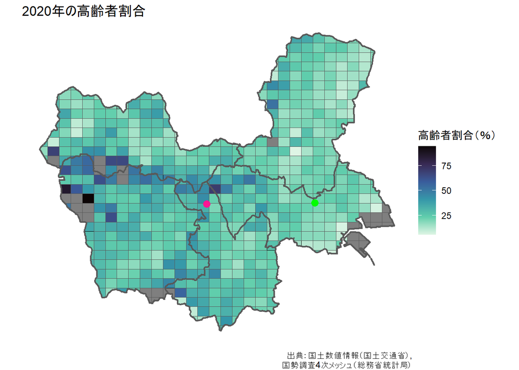

```r
ggplot()+
  geom_sf(data=periphery_mesh, aes(fill=elderly_ratio))+
  scale_fill_viridis_c(option="G", direction=-1)+
  geom_sf(data=Sasayama_ss_sfc,
             color="deeppink", size=3)+
  geom_sf(data=Rokkakubashi_ss_sfc,
             color="green", size=3)+
  geom_sf(data=periphery, fill="NA",
          linewidth=0.8)+
  labs(fill="高齢者割合（％）", caption="出典：国土数値情報（国土交通省）,
       国勢調査4次メッシュ（総務省統計局）")+
  ggtitle("2020年の高齢者割合")+
  theme_void()
```

# 3 商圏の可視化

- 商店街のポイントの一次商圏（半径1.2km）を可視化．
  - `st_buffer()`：円（ポリゴン）を作成．
    - `dist`：円の距離．
    - `set_units()`：単位を付与．ここでは`1200m`を指示．

```r
Sasayama_ss_sfc %>%
  st_buffer(dist=set_units(1200, m)) ->
  Sasayama_buffer

Rokkakubashi_ss_sfc %>%
  st_buffer(dist=set_units(1200, m)) ->
  Rokkakubashi_buffer
```

**商圏の可視化**

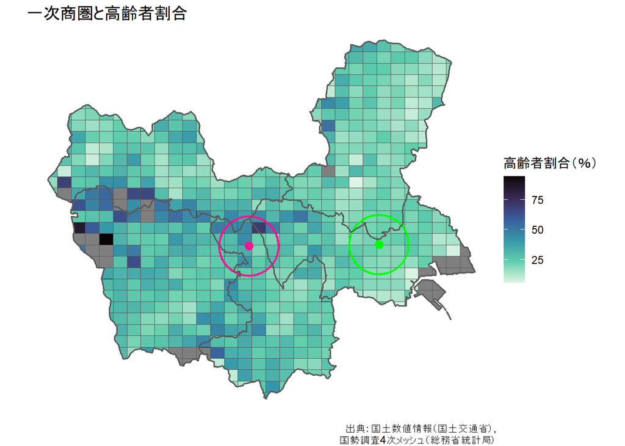

```r
ggplot()+
  geom_sf(data=periphery_mesh, aes(fill=elderly_ratio))+
  scale_fill_viridis_c(option="G", direction=-1)+
  geom_sf(data=Sasayama_ss_sfc,
             color="deeppink", size=3)+
  geom_sf(data=Sasayama_buffer, color="deeppink",
          fill="NA", linewidth=0.8)+
  geom_sf(data=Rokkakubashi_ss_sfc,
             color="green", size=3)+
  geom_sf(data=Rokkakubashi_buffer, color="green",
          fill="NA", linewidth=0.8)+
  geom_sf(data=periphery, fill="NA",
          linewidth=0.6)+
  labs(fill="高齢者割合（％）", caption="出典：国土数値情報（国土交通省）,
       国勢調査4次メッシュ（総務省統計局）")+
  ggtitle("一次商圏と高齢者割合")+
  theme_void()
```